# STATS-418 HW-3

# R package: gbm

```
## Using OOB method...
```

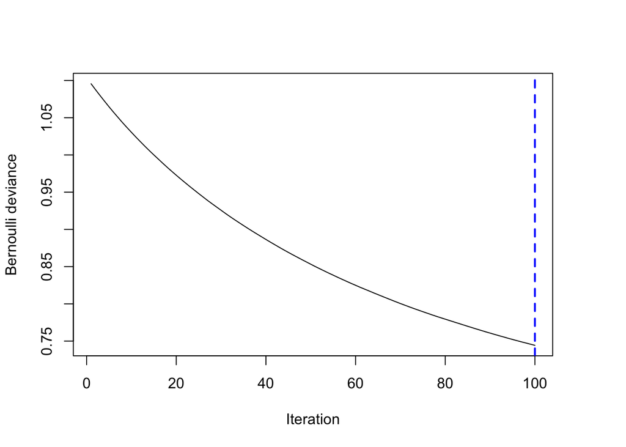

```
## [1] 100
```

```r
set.seed(123)

md1 <- gbm(Y ~ ., data = d_train, distribution = "bernoulli",
          n.trees = 100, interaction.depth = 10, shrinkage = 0.01)
gbm.perf(md1, plot.it = TRUE)
```

```r
yhat <- predict(md1, d_test, n.trees = 100)
GBM_pred <- prediction(yhat, d_test$Y)
performance(GBM_pred, "auc")@y.values[[1]]
```

```
## [1] 0.9028216
```

```
## Using cv method...
```

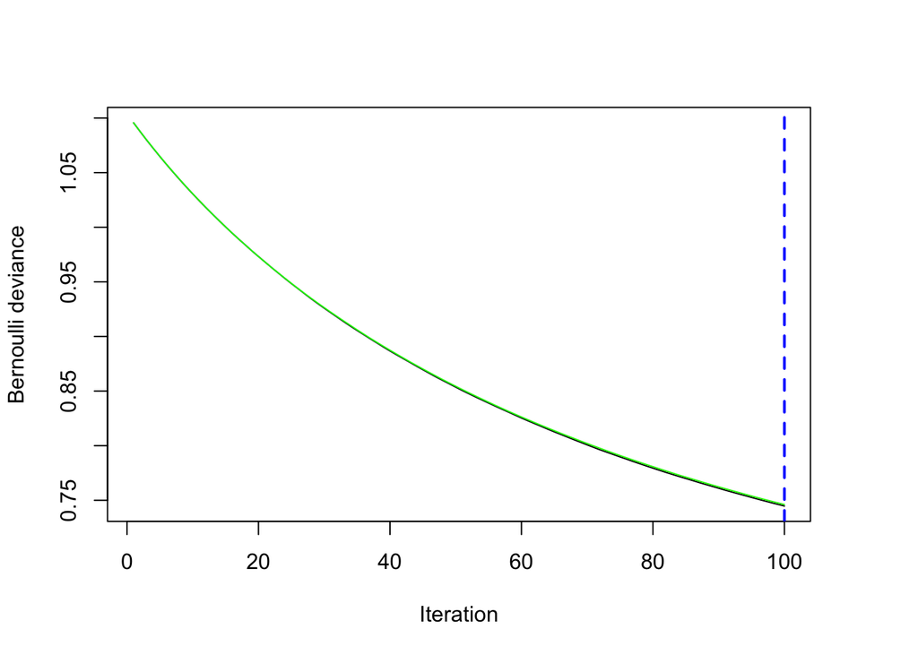

```
## [1] 100
```

```r
md2 <- gbm(Y ~ ., data = d_train, distribution = "bernoulli",
          n.trees = 100, interaction.depth = 10, shrinkage = 0.01, cv.folds = 5)
gbm.perf(md2, plot.it = TRUE)
```

```r
yhat <- predict(md2, d_test, n.trees = 100)
GBM_pred <- prediction(yhat, d_test$Y)
performance(GBM_pred, "auc")@y.values[[1]]
```

```
## [1] 0.9024553
```

```
## Using cv method...
```

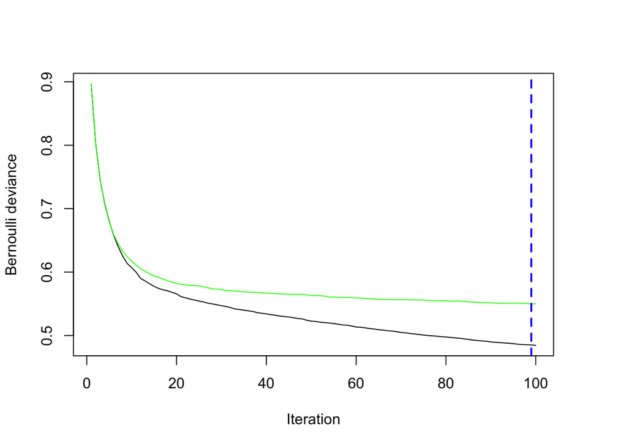

```
## [1] 99
```

```r
md3 <- gbm(Y ~ ., data = d_train, distribution = "bernoulli",
          n.trees = 100, interaction.depth = 10, shrinkage = 0.3, cv.folds = 5)
gbm.perf(md3, plot.it = TRUE)
```

```r
yhat <- predict(md3, d_test, n.trees = gbm.perf(md3, plot.it = FALSE))
```

```
## Using cv method...
```

```r
GBM_pred <- prediction(yhat, d_test$Y)
performance(GBM_pred, "auc")@y.values[[1]]
```

```
## [1] 0.9343011
```

# Xgboost

```r
# without early stop
xgb1 <- xgb.train(data = dxgb_train, nthread = n_proc, objective = "binary:logistic",
                  nround = 200, max_depth = 20, eta = 0.1)

phat <- predict(xgb1, newdata = X_validation)

rocr_pred <- prediction(phat, d_validation$Y)
performance(rocr_pred, "auc")@y.values[[1]]
```

```
## [1] 0.9707713
```

```r
xgb2 <- xgb.train(data = dxgb_train, nthread = n_proc, objective = "binary:logistic",
                    nround = 200, max_depth = 10, eta = 0.1)
phat <- predict(xgb2, newdata = X_validation)
rocr_pred <- prediction(phat, d_validation$Y)
performance(rocr_pred, "auc")@y.values[[1]]
```

```
## [1] 0.9542258
```

```r
# with early stop
xgb3 <- xgb.train(data = dxgb_train, nthread = n_proc, objective = "binary:logistic",
                    nround = 200, max_depth = 10, eta = 0.1,
                   ntrees = 200, learn_rate = 0.1, stopping_rounds=5,
                  stopping_tolerance = 0.0001, stopping_metric="AUC", nbins = 5, seed = 123)
phat <- predict(xgb3, newdata = X_validation)
rocr_pred <- prediction(phat, d_validation$Y)
performance(rocr_pred, "auc")@y.values[[1]]
```

```
## [1] 0.9542258
```

```r
xgb4 <- xgb.train(data = dxgb_train, nthread = n_proc, objective = "binary:logistic",
                    nround = 200, max_depth = 10, eta = 0.1,
                   ntrees = 200, learn_rate = 0.05, stopping_rounds=10,
                  stopping_tolerance = 0.0001, stopping_metric="AUC", nbins = 5, seed = 123)
phat <- predict(xgb4, newdata = X_validation)
rocr_pred <- prediction(phat, d_validation$Y)
performance(rocr_pred, "auc")@y.values[[1]]
```

```
## [1] 0.9542258
```

The last algorithm I used is Gradient Boosting Machine. Here I tuned two parameters, the depth of trees and the learning rate. Although GBM is robust enough to avoid overfitting with increasing trees, high learning rate can lead to overfitting. The depth of trees refers to the number of splits it has to perform on a tree (starting from a single node). So our goal is to reduce the learning rate and increase trees. According to the results, we can see the model xgb1 has the largest AUC, which means it is the best model among all others. For early stopping, it uses regularization to avoid overfitting.